### Lab 3 Solutions

1. Data on New York City weather are in Nexus `lab data files` folder in `NYC_weather.csv`. Save the file to your `business analytics` folder. The data has information on daily precipitation (in tenths of milimeters) and min and max temperatures (in tenths of degree Celsius) as recorded by the Belevedere Tower in Central Park. The data comes from http://www.ncdc.noaa.gov. Note that missing values are indicated as -9999. Load the data into R.

```r
library(tidyverse)
library(stargazer)
weather <- read_csv("NYC_weather.csv")
```

2. Summarize the variables. Are the values reasonable? Are there any missing values? If so, drop the observations that have missing values. How many observations did you loose by dropping these?

```r
glimpse(weather)
```

```
## Observations: 27,746
## Variables: 4
## $ DATE <int> 19400101, 19400102, 19400103, 19400104, 19400105, 1940010...
## $ PRCP <int> 0, 0, 0, 0, 8, 0, 0, 20, 0, 0, 0, 43, 3, 523, 36, 0, 3, 0...
## $ TMAX <int> -44, -22, 6, 0, -17, -11, -33, -44, -17, 11, 0, 22, 33, 1...
## $ TMIN <int> -94, -83, -83, -67, -89, -100, -111, -72, -67, -78, -50, ...
```

```r
summary(weather)
```

```
##       DATE               PRCP               TMAX
##  Min.   :19400101   Min.   :-9999.00   Min.   :-9999.0
##  1st Qu.:19581229   1st Qu.:    0.00   1st Qu.:   83.0
##  Median :19771226   Median :    0.00   Median :  178.0
##  Mean   :19775504   Mean   :   30.87   Mean   :  168.7
##  3rd Qu.:19961222   3rd Qu.:   13.00   3rd Qu.:  261.0
##  Max.   :20151219   Max.   : 1923.00   Max.   :  400.0
##       TMIN
##  Min.   :-9999.00
##  1st Qu.:   17.00
##  Median :   89.00
##  Mean   :   84.28
##  3rd Qu.:  167.00
##  Max.   :  289.00
```

DATE appears to be stored as a numerical variable. It looks like the data starts in 1940 and ends in 2015. The mean of DATE is meaningless. Precipitaion and the two temperature variables have missing values. Let’s get rid of these first before discussing the descriptive statistics. I take note that weather has 27,746 observations.

```r
weather <- weather %>% filter(TMIN!=-9999) %>% filter(TMAX != -9999) %>% filter(PRCP !=-9999)
weather <- as.data.frame(weather)
stargazer(select(weather, PRCP,TMIN,TMAX), type = "text", median=TRUE)
```

```
##
## ===================================================
## Statistic   N     Mean   St. Dev. Min  Median  Max
## ---------------------------------------------------
## PRCP      27,735 32.311   91.852   0     0    1,923
## TMIN      27,735 85.737   92.463  -222   89    289
## TMAX      27,735 169.770 103.351  -133  178    400
## ---------------------------------------------------
```

Dropping missing values reduced the number of observations by 11. We see that average precipitation is 3 millimeters, median precipitation is 0, maximum is nearly 20 centimeters (about 8 inches). Looking and sorting the data in the data viewer I see that this happened in april 2007. I googled “NYC storm 2007” and indeed articles about unprecented rainfall appear. Thre record low temperature is -22 celcius (about -8 Fahrenheit), record high is 40 degree celcius (about 104 Fahrenheit). Overall, these values seem reasonable.

3. Change the `DATE` variable from a ‘numeric’ type to ‘Date’ type. (Hint 1: `as.Date()` does not work on numeric, so you first need to turn `DATE` into character using `as.character()`. Hint 2: Note also that the format of the date is “%Y%m%d” i.e. no dashes between year, month and day.

```r
weather$Date <- as.Date(as.character(weather$DATE), format="%Y%m%d")
```

4. Plot the minimum and maximum tepratures on a time line for the entire period. Then do the same since 2014.

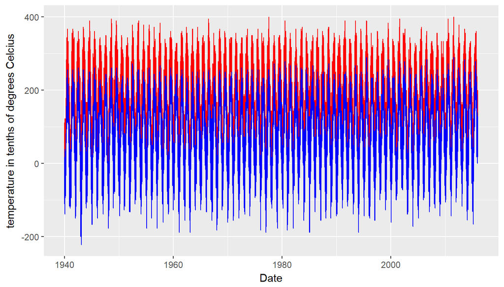

```r
ggplot(weather, aes(x=Date)) +
  geom_line(aes(y=TMAX), color="red") +
  geom_line(aes(y=TMIN), color="blue") +
  ylab("temperature in tenths of degrees Celcius")
```

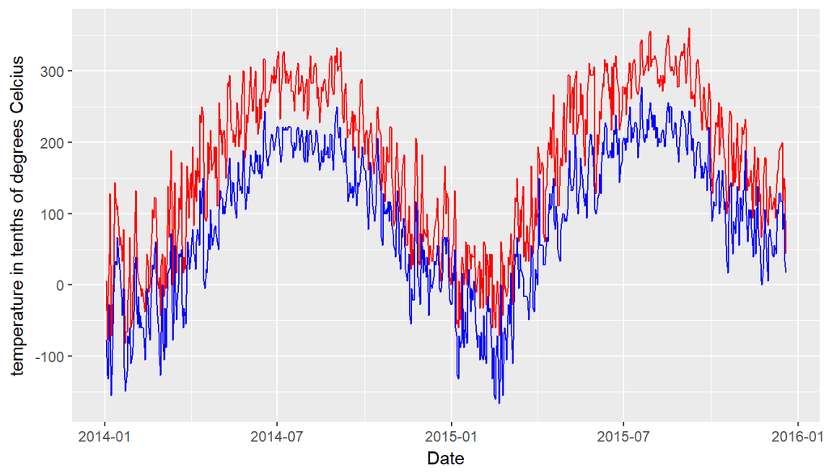

```r
ggplot(filter(weather, Date > as.Date("2014-01-01")), aes(x=Date)) +
  geom_line(aes(y=TMAX), color="red") +
  geom_line(aes(y=TMIN), color="blue") +
  ylab("temperature in tenths of degrees Celcius")
```

5. Load in the daily data on Dow Jones Industrial from Nexus. The file is called `dji.csv`. Calculate daily returns. Check the descriptive stats of your daily return.

```r
dji <- read_csv("dji.csv")
dji <- arrange(dji, Date)
dji$ret <- (dji$DJI-lag(dji$DJI))/lag(dji$DJI)*100
stargazer(as.data.frame(dji), type="text", median=TRUE)
```

```
##
## ===============================================================
## Statistic   N      Mean    St. Dev.    Min   Median     Max
## ---------------------------------------------------------------
## DJI       33,049 2,491.693 4,582.092 28.480  282.890 25,295.870
## ret       33,048   0.026     1.089   -23.523  0.045    15.342
## ---------------------------------------------------------------
```

The descriptive statistics look reasonable. The average mean return is positive. Minimum is December 12, 1914. The second lowest return is Black Monday of October 19, 1987 when the market dropped 20%. The best day March 15, 1933.

6. Merge your daily DJI data with your NYC weather data. Keep only dates that are in both data sets. Which observations do you lose from either dataset?

```r
data <- inner_join(dji,weather, by="Date")
```

The weather data begins in 1940 whereas, the DJI starts in 1896 so we lose any data prior to 1940. Also, the weather data includes weekends and holidays, whereas the DJI data does not, so weekends and holidays are also excluded from the merged dataset. Finally, we lose the data after December 2015 because that is when the weather data ends.

7. What is the correlation between temperature and returns?

```r
cor(data$ret, data$TMIN, use = "complete.obs")
```

```
## [1] -0.01501664
```

```r
cor(data$ret, data$TMAX, use = "complete.obs")
```

```
## [1] -0.009484893
```

The correlation coefficient is very close to zero indicating little or no relation between temperature and returns.

8. Save the merged data into a .csv file. Make sure that you are in your business analytics `project` so that R knows to save into that folder.

```r
write_csv(data, "weather and dji.csv")
```